# Ishan Gupta

Aspiring Quantitative Researcher | UNC Chapel Hill

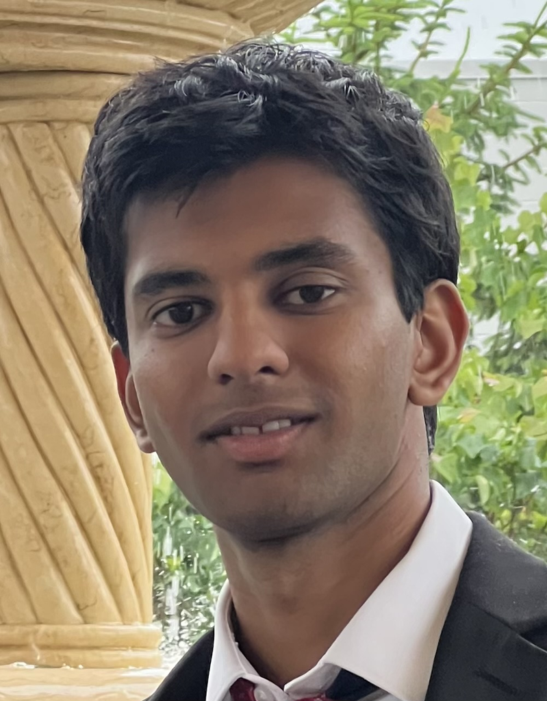

## About Me

I am an aspiring data scientist studying at UNC Chapel Hill currently pursuing a **B.S.-M.S. in Statistics & Analytics** with a double major in **Mathematics**.

My current interests include:

- Quantitative Finance
- Algorithmic Game Theory
- Sports Analytics

When I’m not coding, you can find me playing pickleball, poker, or trying a new cuisine.

## Education

**University of North Carolina at Chapel Hill**  
B.S.-M.S. in Statistics & Analytics  
Expected Graduation From B.S: Dec 2027  
Expected Graduation From M.S: Dec 2028  
GPA: 3.93/4.0

Relevant Coursework: Statistical Methods I & II; Economics Data Analysis; Calculus I, II, III; Data Science in R & Python; Algebraic Geometry; Methods of Data Science

**High School**  
Graduation: Jun 2024  
GPA: 3.8/4.0 ACT: 35/36

## Experience

**Research Assistant**  
Rutgers University / Department of Mathematics  
Sept. 2024 – Present  
• Mathematics research on division algorithms, creating optimal allocations for multiple agents.  
• Wrote foundational proof for applications in game theory and computational social choice.  
• Preparing results for submission to the highest tier of computer science conferences (AAA conference).

**Private Equity Analyst Intern**  
Next Haven Group  
Jun 2024 – Aug 2024  
• Conducted outreach to 30+ potential acquisition targets weekly.  
• Researched company financials to ensure alignment with the firm’s investment criteria.  
• Collaborated with the investment team to identify promising candidates for deeper due diligence.

**Financial Intern**  
National Junior Tennis and Learning of Trenton (NJTLT)  
May 2024 - Jun 2024  
• Piloted full review of the organization’s financial records and identified areas for improvement.  
• Uncovered $5,000+ in potential savings by spotting missing information and securing funding.  
• Led a fundraising effort that raised over $10,000 in one day for underserved youth.

## Projects

**Optimal Stopping In Marble Game Using Bayesian Analysis**  
*Tools: Bayesian Analysis, Mathematical Probability, Optimization*  
Given a game with a bag of blue and red marbles where drawing a blue marble increases our value by 1 dollar and drawing a red marble decreases our value by 1 dollar, can we use probability distributions and Bayeisan anaylsis to find the optimal stopping point if we don’t know the number of blue and red marbles, only the total number of marbles? [Paper](https://github.com/ishangupta8047/Optimal-Stopping-Game/blob/main/Optimal_Stopping_With_Unknown_Marbles.pdf)

**Don’t Bet On Sunshine: A Modern Re-Examination of Weather Effects on Stock Market Behavior**  
*Tools: Python, Matplotlib, Regression Analysis, Seaborn*  
I revisit the long-standing behavioral hypothesis that weather affects investor mood and, consequently, financial market behavior. I estimate a series of univariate and multivariate linear regressions using return, intraday volatility, and trading volume (both raw and log-transformed) as dependent variables. I also test for delayed effects using lagged weather variables and behavioral responses to short-term temperature changes. [Paper](https://papers.ssrn.com/sol3/papers.cfm?abstract_id=5446314)

## Skills

**Languages & Tools**  
R • Python • SQL • GitHub • R Markdown

**Data Science Stack**  
tidyverse • tidymodels • scikit-learn • pandas • numpy • ggplot2 • seaborn • plotly

**Other**  
LaTeX • HTML/CSS

Last updated: February 2026